# Wk8_Take_Home

Sam Fritz-Schreck

2024-02-28

## Tasks

Perform the following tasks:

### Train/Test Split

```
Conduct a training/test split of the data, building a 20% held out test dataset
```

```r
data = read.csv("winequality-red.csv")

data$quality = as.factor(data$quality)
data[,c(1:11)] = scale(data[,c(1:11)])

set.seed(123)
# randomly select 20% of index values for test
test_size <- .2
index_list <- index_list <- seq(1, dim(data)[1])
test_index <- sample(index_list, round(test_size*dim(data)[1]), replace=FALSE)
# Split dataset
Train <- data[-(test_index),] # indexes not sampled for test
Test <- data[test_index,]     # indexes samples for test
```

### Multinom Regression

```
Use what you learned in OA4106 to fit the best linear regression model you can (consider feature selection etc.) to the data to predict wine quality; use this model as a performance “baseline”
```

```r
mlr = multinom(quality~., data=Train)
step_mlr = step(mlr, direction="both")
```

```
## Start:  AIC=2422.12
## quality ~ fixed.acidity + volatile.acidity + citric.acid + residual.sugar +
##     chlorides + free.sulfur.dioxide + total.sulfur.dioxide +
##     density + pH + sulphates + alcohol
##
## trying - fixed.acidity
## trying - volatile.acidity
## trying - citric.acid
## trying - residual.sugar
## trying - chlorides
## trying - free.sulfur.dioxide
## trying - total.sulfur.dioxide
## trying - density
## trying - pH
## trying - sulphates
## trying - alcohol
##                        Df      AIC
## <none>                 60 2422.122
## - fixed.acidity        55 2422.188
## - free.sulfur.dioxide  55 2422.948
## - density              55 2424.246
## - citric.acid          55 2424.419
## - pH                   55 2424.852
## - residual.sugar       55 2428.116
## - chlorides            55 2431.371
## - total.sulfur.dioxide 55 2462.084
## - sulphates            55 2476.214
## - volatile.acidity     55 2478.576
## - alcohol              55 2490.127
```

```r
PredClassMLR = predict(step_mlr, newdata = Test)

confusionMatrix(PredClassMLR, Test$quality)
```

```
## Confusion Matrix and Statistics
##
##           Reference
## Prediction   3   4   5   6   7   8
##          3   0   1   1   0   0   0
##          4   0   0   0   0   0   0
##          5   1   7 103  39   1   0
##          6   0   6  40  70  24   1
##          7   0   0   1  13   8   3
##          8   0   0   0   1   0   0
##
## Overall Statistics
##
##                Accuracy : 0.5656
##                  95% CI : (0.5094, 0.6207)
##     No Information Rate : 0.4531
##     P-Value [Acc > NIR] : 3.505e-05
##
##                   Kappa : 0.2864
##
##  Mcnemar's Test P-Value : NA
##
## Statistics by Class:
##
##                      Class: 3 Class: 4 Class: 5 Class: 6 Class: 7 Class: 8
## Sensitivity          0.000000  0.00000   0.7103   0.5691  0.24242 0.000000
## Specificity          0.993730  1.00000   0.7257   0.6396  0.94077 0.996835
## Pos Pred Value       0.000000      NaN   0.6821   0.4965  0.32000 0.000000
## Neg Pred Value       0.996855  0.95625   0.7515   0.7039  0.91525 0.987461
## Prevalence           0.003125  0.04375   0.4531   0.3844  0.10312 0.012500
## Detection Rate       0.000000  0.00000   0.3219   0.2188  0.02500 0.000000
## Detection Prevalence 0.006250  0.00000   0.4719   0.4406  0.07812 0.003125
## Balanced Accuracy    0.496865  0.50000   0.7180   0.6043  0.59160 0.498418
```

```
Execute the deep (machine) learning process discussed in the lecture to build a deep learning model for predicting wine quality (note that this could be conducted as a multinomial classification problem but you should take a regresson approach)
```

### Baseline model

```
    Fit a baseline model
```

```r
predictors_train = as.matrix(Train[,c(1:11)])
predictors_test = as.matrix(Test[,c(1:11)])
response_train = as.numeric(Train$quality)
response_test = as.numeric(Test$quality)

# Define the epochs we'll consider
epochs <- 300

# Helper function for display training progress by printing a single dot for each completed epoch.
print_dot_callback <- callback_lambda(
  on_epoch_end = function(epoch, logs) {
    if (epoch %% 80 == 0) cat("\n")
    cat(".")
  }
)

# Convert the response variable to a matrix of one-hot encoded vectors
response_train_onehot <- to_categorical(as.integer(response_train) - 1)  # Minus 1 to start labels from 0
response_test_onehot =  to_categorical(as.integer(response_test) - 1)  # Minus 1 to start labels from 0



# Build the model for ordinal classification
model_ordinal <- keras_model_sequential() %>%
  layer_dense(units = 6, activation = "relu", input_shape = dim(predictors_train)[2]) %>%
  #layer_dropout(rate = 0.2) %>%
  layer_dense(units = 6, activation = "softmax")  # Use softmax for multiclass classification

# Use categorical crossentropy loss for ordinal data
model_ordinal %>% compile(
  loss = "categorical_crossentropy",
  optimizer = optimizer_adam(),
  metrics = list("accuracy")
)

# Train the model
history_ordinal <- model_ordinal %>% fit(
  predictors_train,
  response_train_onehot,
  epochs = epochs,
  validation_split = 0.2,
  verbose = 0,
  callbacks = list(print_dot_callback)
)
```

```
##
## ................................................................................
## ................................................................................
## ................................................................................
## ............................................................
```

```r
# Evaluate on the test set
model_ordinal %>% evaluate(predictors_test, response_test_onehot)
```

```
## 10/10 - 0s - loss: 1.0104 - accuracy: 0.5781 - 18ms/epoch - 2ms/step
```

```
##     loss accuracy
## 1.010427 0.578125
```

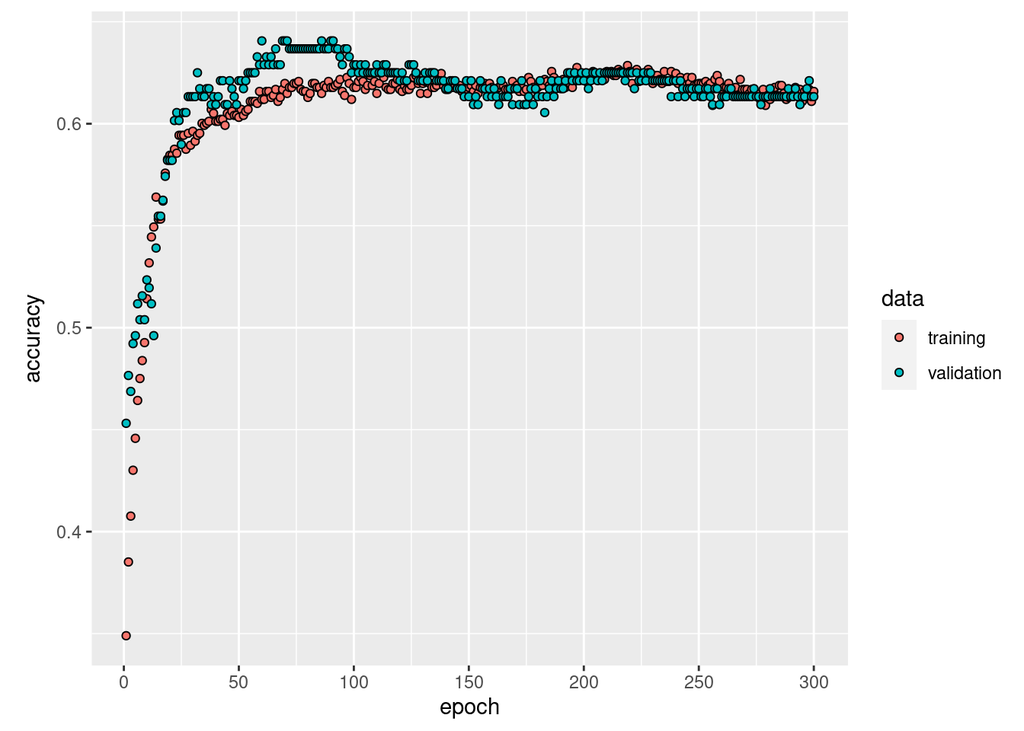

```r
plot(history_ordinal, metrics='accuracy', smooth=F)
```

### Overfitting

```
    Overfit a model
```

```r
# Build the model for ordinal classification
model_overfit <- keras_model_sequential() %>%
  layer_dense(units = 20, activation = "relu", input_shape = dim(predictors_train)[2]) %>%
  layer_dense(units=20, activation = 'relu') %>%
  layer_dense(units = 6, activation = "softmax")  # Use softmax for multiclass classification

# Use categorical crossentropy loss for ordinal data
model_overfit %>% compile(
  loss = "categorical_crossentropy",
  optimizer = optimizer_adam(),
  metrics = list("accuracy")
)

# Train the model
history_overfit <- model_overfit %>% fit(
  predictors_train,
  response_train_onehot,
  epochs = epochs,
  validation_split = 0.2,
  verbose = 0,
  callbacks = list(print_dot_callback)
)
```

```
##
## ................................................................................
## ................................................................................
## ................................................................................
## ............................................................
```

```r
# Evaluate on the test set
model_overfit %>% evaluate(predictors_test, response_test_onehot)
```

```
## 10/10 - 0s - loss: 1.2768 - accuracy: 0.5813 - 17ms/epoch - 2ms/step
```

```
##     loss accuracy
## 1.276821 0.581250
```

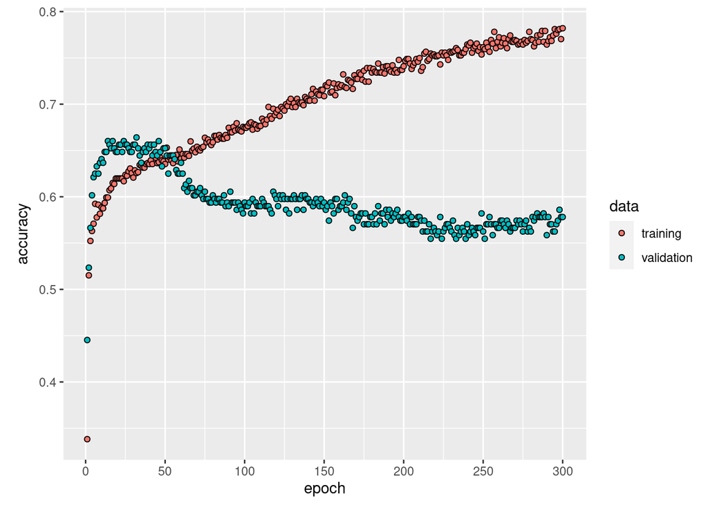

```r
plot(history_overfit, metrics='accuracy', smooth=F)
```

### Regularization

```
    Use regularization techniques and cross-validation to develop a good deep learning model.
```

```r
# Build the model for regular classification
model_regular <- keras_model_sequential() %>%
  layer_dense(units = 20, activation = "relu", input_shape = dim(predictors_train)[2],
              kernel_regularizer = regularizer_l2(0.01)) %>%
  layer_dropout(rate = 0.2) %>%
  layer_dense(units =6, activation = "softmax")  # Use softmax for multiclass classification

# Use categorical crossentropy loss for regular data
model_regular %>% compile(
  loss = "categorical_crossentropy",
  optimizer = optimizer_adam(learning_rate = 0.001),
  metrics = list("accuracy")
)

# Train the model
history_regular <- model_regular %>% fit(
  predictors_train,
  response_train_onehot,
  epochs = epochs,
  validation_split = 0.2,
  verbose = 0,
  callbacks = list(print_dot_callback)
)
```

```
##
## ................................................................................
## ................................................................................
## ................................................................................
## ............................................................
```

```r
# Evaluate on the test set
model_regular %>% evaluate(predictors_test, response_test_onehot)
```

```
## 10/10 - 0s - loss: 0.9873 - accuracy: 0.5844 - 17ms/epoch - 2ms/step
```

```
##      loss  accuracy
## 0.9872766 0.5843750
```

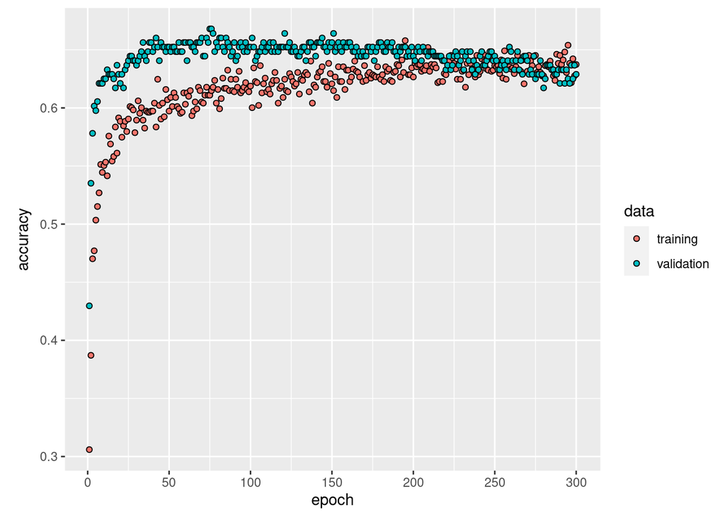

[output not shown]

```r
plot(history_regular, metrics='accuracy', smooth=F)
```

##Summary Provide a summary and discussion of your work in written form (.docx or .pdf) that includes the following:

```
Summarize the model/feature selection process you used to fit your linear regression model
```

Leveraged a step multinomial regression to identify significant features

```
Provide a summary of the fitted linear regression model (i.e. model summary)
```

```r
summary(step_mlr)
```

```
## Call:
## multinom(formula = quality ~ fixed.acidity + volatile.acidity +
##     citric.acid + residual.sugar + chlorides + free.sulfur.dioxide +
##     total.sulfur.dioxide + density + pH + sulphates + alcohol,
##     data = Train)
##
## Coefficients:
##   (Intercept) fixed.acidity volatile.acidity citric.acid residual.sugar
## 4    5.176915   -0.02524920        -1.306444  -0.7800967      0.7334932
## 5    8.152740   -0.72423969        -1.992416  -1.0080353      0.2064675
## 6    8.341390   -0.53125935        -2.480638  -1.2778877      0.2468323
## 7    6.225514    0.07274048        -2.715867  -0.8846543      0.5719357
## 8    2.054531   -0.98725040        -1.797110  -0.1578360     -0.5621784
##    chlorides free.sulfur.dioxide total.sulfur.dioxide    density         pH
## 4 -0.5249949           -1.942918             2.718132 -1.5144250 -0.5116646
## 5 -0.6580162           -1.725775             3.242449 -0.8019754 -1.2506655
## 6 -0.7853380           -1.488853             2.665573 -0.8398408 -1.3222341
## 7 -1.0933671           -1.439684             2.398154 -1.5287689 -1.1133972
## 8 -2.4575703           -1.312059             1.741361 -1.2404868 -2.2415962
##   sulphates   alcohol
## 4 0.6630175 0.9423046
## 5 0.5272014 1.0877288
## 6 0.9344009 1.9915093
## 7 1.4410670 2.3855619
## 8 1.7695537 3.2149558
##
## Std. Errors:
##   (Intercept) fixed.acidity volatile.acidity citric.acid residual.sugar
## 4    1.516572      1.363305        0.5756785   0.8874917      0.4539020
## 5    1.505062      1.295981        0.5688283   0.8520770      0.4379397
## 6    1.505062      1.297871        0.5734683   0.8556251      0.4408164
## 7    1.512385      1.313937        0.5919657   0.8717303      0.4516989
## 8    1.738401      1.551823        0.7389485   1.0470988      0.9511636
##   chlorides free.sulfur.dioxide total.sulfur.dioxide  density        pH
## 4 0.3730343            1.042394             1.681578 1.126596 0.8211180
## 5 0.3379621            1.010894             1.659123 1.075213 0.7917209
## 6 0.3436912            1.012140             1.660436 1.078663 0.7938940
## 7 0.3745537            1.020255             1.667889 1.097490 0.8073786
## 8 0.9829982            1.121810             1.767102 1.362793 0.9875555
##   sulphates   alcohol
## 4 0.6758999 0.9343499
## 5 0.6354588 0.8963322
## 6 0.6375230 0.8989191
## 7 0.6437535 0.9094048
## 8 0.6947931 1.0660694
##
## Residual Deviance: 2302.122
## AIC: 2422.122
```

```
Briefly summarize (you do not need to provide all of the models etc.) the model fitting procedure you employed to develop your deep learning model. Briefly describe the size and network structure of the various models. Briefly describe the regularization procedures you tried.
```

Started with 6 unit layers for the base model as the output is 6 classes. Then tried to over fit starting with 40 units and dialed back until it seemed to not be diverging too much. Once I had the overfit model, I applied l1, l2, and elastic regularization to pick the best technique. Then added dropout and varied the rate.

```
Summarize the selected model and describe why/how you chose that particular model (if this is explained above you do not need to repeat yourself).
```

```r
summary(model_regular)
```

[output not shown]

```
Provide performance comparisons on the test dataset between linear regression and your best deep learning model.
```

```r
confusionMatrix(PredClassMLR, Test$quality)
```

```
## Confusion Matrix and Statistics
##
##           Reference
## Prediction   3   4   5   6   7   8
##          3   0   1   1   0   0   0
##          4   0   0   0   0   0   0
##          5   1   7 103  39   1   0
##          6   0   6  40  70  24   1
##          7   0   0   1  13   8   3
##          8   0   0   0   1   0   0
##
## Overall Statistics
##
##                Accuracy : 0.5656
##                  95% CI : (0.5094, 0.6207)
##     No Information Rate : 0.4531
##     P-Value [Acc > NIR] : 3.505e-05
##
##                   Kappa : 0.2864
##
##  Mcnemar's Test P-Value : NA
##
## Statistics by Class:
##
##                      Class: 3 Class: 4 Class: 5 Class: 6 Class: 7 Class: 8
## Sensitivity          0.000000  0.00000   0.7103   0.5691  0.24242 0.000000
## Specificity          0.993730  1.00000   0.7257   0.6396  0.94077 0.996835
## Pos Pred Value       0.000000      NaN   0.6821   0.4965  0.32000 0.000000
## Neg Pred Value       0.996855  0.95625   0.7515   0.7039  0.91525 0.987461
## Prevalence           0.003125  0.04375   0.4531   0.3844  0.10312 0.012500
## Detection Rate       0.000000  0.00000   0.3219   0.2188  0.02500 0.000000
## Detection Prevalence 0.006250  0.00000   0.4719   0.4406  0.07812 0.003125
## Balanced Accuracy    0.496865  0.50000   0.7180   0.6043  0.59160 0.498418
```

```r
model_regular %>% evaluate(predictors_test, response_test_onehot)
```

```
## 10/10 - 0s - loss: 0.9873 - accuracy: 0.5844 - 20ms/epoch - 2ms/step
```

```
##      loss  accuracy
## 0.9872766 0.5843750
```

```
Do you think “the juice is worth the squeeze”? Why or why not?
```

The deep learning accuracy is contained within the MLR model’s 95% confidence interval of (0.5094, 0.6207) so we cannot say that the deep learning model is more accurate than the MLR.

```
Provide a (scatter) plot of your predictions vs. the actual assigned quality for your selected linear regression model and your selected deep learning model.
```

As I am classifying, I’ll do a confusion matrix.

```r
confusionMatrix(PredClassMLR, Test$quality)
```

```
## Confusion Matrix and Statistics
##
##           Reference
## Prediction   3   4   5   6   7   8
##          3   0   1   1   0   0   0
##          4   0   0   0   0   0   0
##          5   1   7 103  39   1   0
##          6   0   6  40  70  24   1
##          7   0   0   1  13   8   3
##          8   0   0   0   1   0   0
##
## Overall Statistics
##
##                Accuracy : 0.5656
##                  95% CI : (0.5094, 0.6207)
##     No Information Rate : 0.4531
##     P-Value [Acc > NIR] : 3.505e-05
##
##                   Kappa : 0.2864
##
##  Mcnemar's Test P-Value : NA
##
## Statistics by Class:
##
##                      Class: 3 Class: 4 Class: 5 Class: 6 Class: 7 Class: 8
## Sensitivity          0.000000  0.00000   0.7103   0.5691  0.24242 0.000000
## Specificity          0.993730  1.00000   0.7257   0.6396  0.94077 0.996835
## Pos Pred Value       0.000000      NaN   0.6821   0.4965  0.32000 0.000000
## Neg Pred Value       0.996855  0.95625   0.7515   0.7039  0.91525 0.987461
## Prevalence           0.003125  0.04375   0.4531   0.3844  0.10312 0.012500
## Detection Rate       0.000000  0.00000   0.3219   0.2188  0.02500 0.000000
## Detection Prevalence 0.006250  0.00000   0.4719   0.4406  0.07812 0.003125
## Balanced Accuracy    0.496865  0.50000   0.7180   0.6043  0.59160 0.498418
```

```r
# Get the raw predicted probabilities for each class
predictions_prob <- model_regular %>% predict(predictors_test)
```

```
## 10/10 - 0s - 51ms/epoch - 5ms/step
```

```r
# Convert predicted probabilities to class labels
predicted_labels <- factor(max.col(predictions_prob) - 1, levels = 0:(ncol(predictions_prob)-1))

# Convert response_test_onehot to class labels
actual_labels <- factor(max.col(response_test_onehot) - 1, levels = 0:(ncol(response_test_onehot)-1))

# Create confusion matrix
conf_matrix <- confusionMatrix(predicted_labels, actual_labels)

# Print the confusion matrix
print(conf_matrix)
```

```
## Confusion Matrix and Statistics
##
##           Reference
## Prediction   0   1   2   3   4   5
##          0   0   0   0   0   0   0
##          1   0   0   0   0   0   0
##          2   1   9 101  37   1   0
##          3   0   5  43  75  21   2
##          4   0   0   1  11  11   2
##          5   0   0   0   0   0   0
##
## Overall Statistics
##
##                Accuracy : 0.5844
##                  95% CI : (0.5282, 0.6389)
##     No Information Rate : 0.4531
##     P-Value [Acc > NIR] : 1.666e-06
##
##                   Kappa : 0.3137
##
##  Mcnemar's Test P-Value : NA
##
## Statistics by Class:
##
##                      Class: 0 Class: 1 Class: 2 Class: 3 Class: 4 Class: 5
## Sensitivity          0.000000  0.00000   0.6966   0.6098  0.33333   0.0000
## Specificity          1.000000  1.00000   0.7257   0.6396  0.95122   1.0000
## Pos Pred Value            NaN      NaN   0.6779   0.5137  0.44000      NaN
## Neg Pred Value       0.996875  0.95625   0.7427   0.7241  0.92542   0.9875
## Prevalence           0.003125  0.04375   0.4531   0.3844  0.10312   0.0125
## Detection Rate       0.000000  0.00000   0.3156   0.2344  0.03438   0.0000
## Detection Prevalence 0.000000  0.00000   0.4656   0.4562  0.07812   0.0000
## Balanced Accuracy    0.500000  0.50000   0.7111   0.6247  0.64228   0.5000
```

```
Which of these modeling approaches would you employ as an investor (early buyer of wine for later resale at a profit)? Which of these modeling approaches would you employ as a vitner? Why?
```

As an investor, I don’t care necessarily about what features make a wine higher quality so I would be willing to spend more time tuning the deep learning model to gain the greatest accuracy. As a vitner, I would want to know what features contribute positively or negatively to the overall quality so the MLR model is preferable.

Submission Instructions

For this weekly lab assignment, you should submit:

```
An R sript file named Lastname_FirstInitial_DeepLearning.R that contains all of your code for executing the tasks above.

A written summary/discussion of your work (as discussed above) in .docx or .pdf format.
```